# R Notebook

# Final Assignment - Practical Machine Learning - Coursera

## Introduction and background

### Objective:

One thing that people regularly do is quantify how much of a particular activity they do, but they rarely quantify how well they do it. In this project, the goal was to use data from accelerometers on the belt, forearm, arm, and dumbell of 6 participants and *predict* how well they were doing the excercize compared to different compared movements:

- exactly according to the specification (Class A),
- throwing the elbows to the front (Class B)
- lifting the dumbbell only halfway (Class C)
- lowering the dumbbell only halfway (Class D)
- throwing the hips to the front (Class E)

## Review Criteria:

The goal of this project is to predict the manner in which they did the exercise. This is the “classe” variable in the training set. You may use any of the other variables to predict with. You should create a report describing how you built your model, how you used cross validation, what you think the expected out of sample error is, and why you made the choices you did. You will also use your prediction model to predict 20 different test cases.

### Background:

Using devices such as Jawbone Up, Nike FuelBand, and Fitbit it is now possible to collect a large amount of data about personal activity relatively inexpensively. These type of devices are part of the quantified self movement – a group of enthusiasts who take measurements about themselves regularly to improve their health, to find patterns in their behavior, or because they are tech geeks. One thing that people regularly do is quantify how much of a particular activity they do, but they rarely quantify how well they do it. In this project, your goal will be to use data from accelerometers on the belt, forearm, arm, and dumbell of 6 participants. They were asked to perform barbell lifts correctly and incorrectly in 5 different ways. More information is available from the website here: http://web.archive.org/web/20161224072740/http:/groupware.les.inf.puc-rio.br/har (see the section on the Weight Lifting Exercise Dataset).

### Data & Material

The training data for this project are available here:

https://d396qusza40orc.cloudfront.net/predmachlearn/pml-training.csv

The test data are available here:

https://d396qusza40orc.cloudfront.net/predmachlearn/pml-testing.csv

Standard laptop PC for model prediction.

## Results

### data exploration & identification of important predictor variables

### dimension of the datasets

#### pca plot

**plot1**  
The data is mainly distributed by the training individuals looking at the different PC

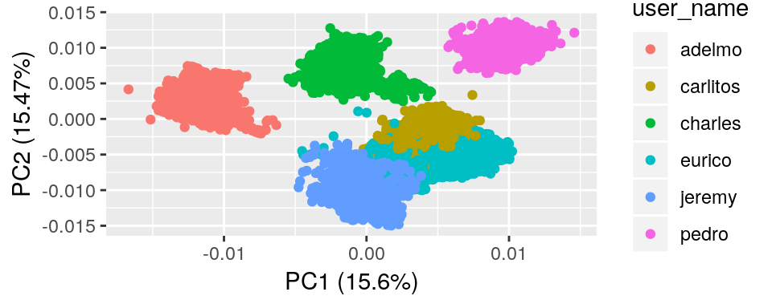

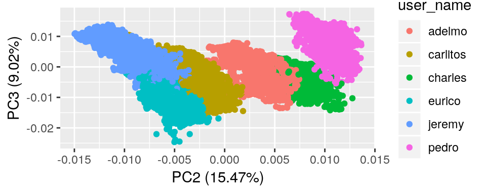

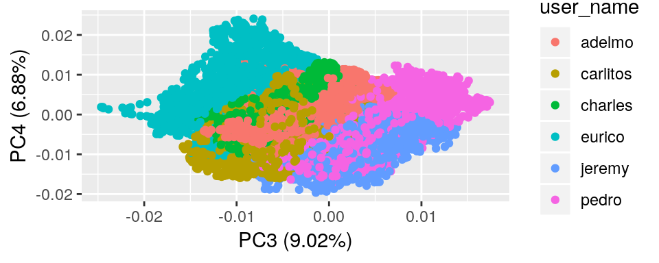

**plot2**  
When plotting the different “classe” variables it appears that there is **no** clear difference between the “classes” and that they get distributed well. They rather get distributed by individuals who performed the test. Therefore, I would like to identify key variables.

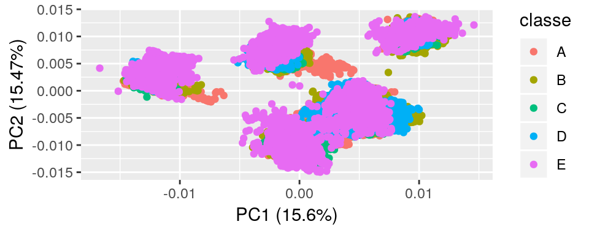

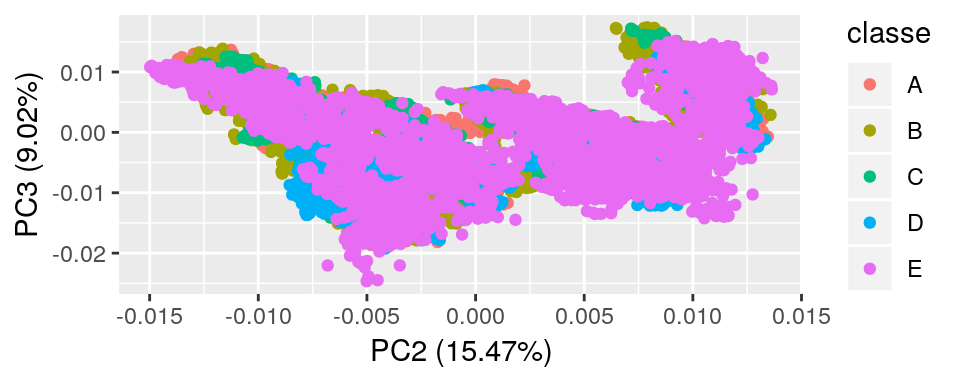

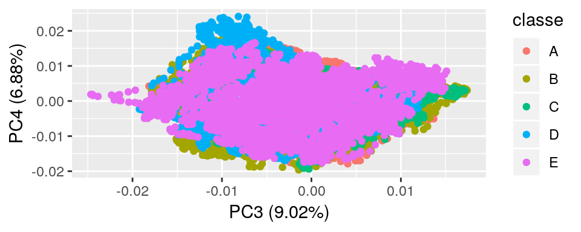

### reducing the number variables

Because there are many variables (160) in the dataset and the model prediction runs on a normal PC the variable reduction will save time and might reduce the risk of overfitting.

**plot3** variable selection out of the dataset

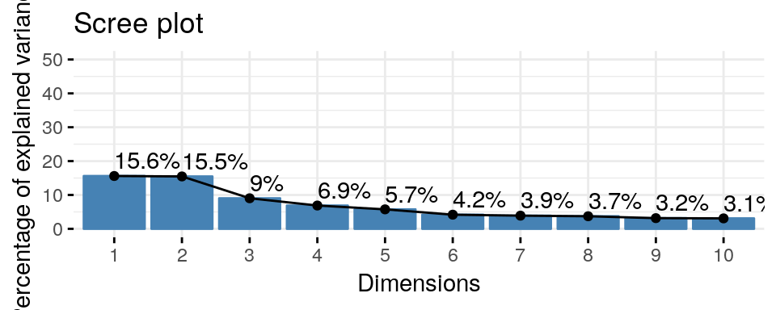

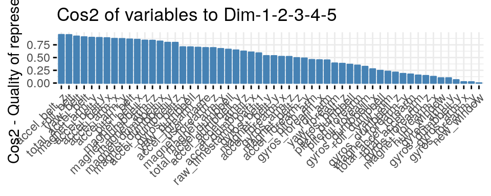

```r
x <- as.data.frame(trainingdata_NArm_tidy.outRM.selected[,-c(1,which(colnames(trainingdata_NArm_tidy.outRM.selected) == "classe"))])
y <- trainingdata_NArm_tidy.outRM.selected$classe

fitControl <- trainControl(method = "cv",
                           number = 5,
                           allowParallel = TRUE)

cluster <- makeCluster(detectCores() - 1) # convention to leave 1 core for OS
registerDoParallel(cluster)

mod2 <- train(x,y,method="rf", data=trainingdata_NArm_tidy.outRM.selected, trControl = fitControl, ntree=25)

stopCluster(cluster)
registerDoSEQ()
```

**Explanation why I choose this model:**  
I use parallel computing to accelerate the process. The Random Forest method is used because it is a powerful method as in the lectures explained and might be advantageous over a “glm” or “lm”. I use here number of trees: 25. In addition random forest has been also used in the publication underlying this data. To improve our prediction I am using here a 5 fold cross-validation resampling technique. As an alternative bootstrapping technique could have been used.

[why to use parallel computing in this assignment](https://github.com/lgreski/datasciencectacontent/blob/master/markdown/pml-randomForestPerformance.md)

```r
mod2$finalModel
```

```
##
## Call:
##  randomForest(x = x, y = y, ntree = 25, mtry = param$mtry, data = ..1)
##                Type of random forest: classification
##                      Number of trees: 25
## No. of variables tried at each split: 15
##
##         OOB estimate of  error rate: 0.34%
## Confusion matrix:
##      A    B    C    D    E  class.error
## A 5574    4    0    0    0 0.0007171029
## B    8 3779    7    2    0 0.0044783983
## C    0   10 3406    6    0 0.0046756283
## D    0    1   16 3190    9 0.0080845771
## E    0    0    0    4 3603 0.0011089548
```

**crossvalidation on a training subset split at the beginning** (which is not included in the model building of course)

```r
crossvalidpredict.select <- crossvaliddata[,grepl(colnames(crossvaliddata), pattern =paste(patternmatch, collapse = "|"))]
crossvalidpredict <- predict(mod2, crossvalidpredict.select)
table(crossvalidpredict.select$classe,crossvalidpredict)
```

```
##    crossvalidpredict
##       A   B   C   D   E
##   A 837   0   0   0   0
##   B   0 569   0   0   0
##   C   0   0 513   0   0
##   D   0   0   0 482   0
##   E   0   0   0   0 541
```

```r
accuracy(crossvalidpredict.select$classe,crossvalidpredict)[1]
```

```
## $PCC
## [1] 100
```

**The evaluation of the test set**

```r
testing.selected  <- testingdata[,grepl(colnames(testingdata), pattern =paste(patternmatch, collapse = "|"))]
pred <- predict(mod2, testing.selected)
pred
```

```
##  [1] B A B A A E D B A A B C B A E E A B B B
## Levels: A B C D E
```

## Conclusion

Thank you for your time and grading.